# Sounds of San Anto

## Most Common Genres

Import artistsGenre worksheet from excel file.

```r
artistsGenre <- read_excel("san_anto_1.xlsx", sheet = "artistsGenre")
```

Keep only the first instance of artist genre from the excel table and join main df with new artistsGenre df via left join.

```r
artist_genres_clean <- artistsGenre %>% distinct(Name, .keep_all = TRUE)
Artist_Genres_df <- my_data %>% left_join(artist_genres_clean, by = c("Artist" = "Name"))
```

Find & plot the top 20 most popular genres

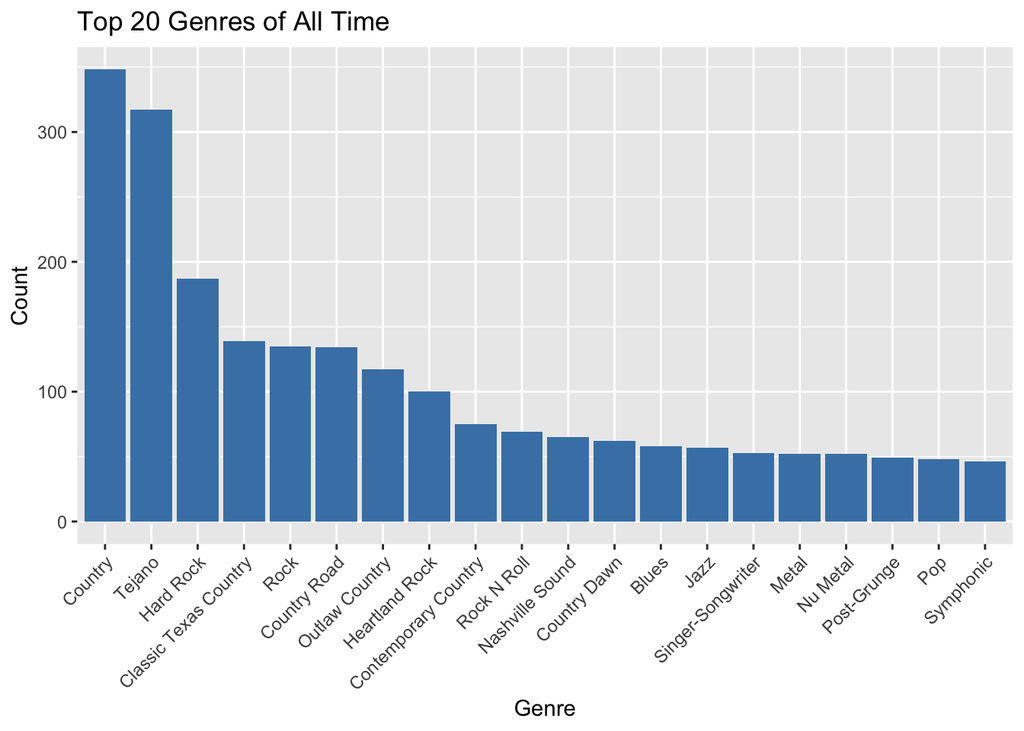

```r
top_genres_all_time <- Artist_Genres_df %>%
  select(Genres) %>%
  filter(!is.na(Genres), !Genres %in% c("Unknown")) %>%
  count(Genres) %>% arrange(desc(n))
top_20_genres_all_time <- head(n=20, top_genres_all_time)
ggplot(top_20_genres_all_time, aes(reorder(Genres, -n), n)) + geom_col(
  fill = "steelblue") +
  labs(
    title = "Top 20 Genres of All Time",
    x = "Genre",
    y = "Count"
  ) + theme(
    axis.text.x = element_text(angle = 45, hjust = 1)

    )
```

From the above plot we continue to see the bias the original data set author had for Country music. We see that Country dominates but if you combine all country subgenres (Country, Classic Texas Country, Country Road, Outlaw Country, Heartland Rock, Contemporary Country, Nashville Sound) the gap over Tejano is even larger, which is worth noting. Tejano at #2 is still significant given how undercounted it likely is due to the collector bias.

Many of the genres in this dataset are highly specific micro-genres, which fragments the data and makes it harder to see broader trends. Consolidating subgenres (e.g. grouping all country variants, all metal variants) into parent categories would give a cleaner picture of SA’s musical identity.

An additional analysis that can be made is finding the most popular genre for each decade.